# datascience_final

2023-12-25

#### Ridwan Ahmed Arman (21-44504-1)

#### Nafis Alam Siddiquee (20-43218-1)

# Dataset Description

Customer churn is the business term that describes how many and at what rate customers stop using a product or service or stop doing business with a company altogether. The dataset that we’ll be using to solve this problem contains customer data, where each entry in the dataset represents one customer. For each customer, there are several features that describe the customer’s relationship with the bank and information about the customer’s finances. Additionally, there’s metadata for each customer, like name, gender, and customer identification number.

Main dataset https://www.kaggle.com/datasets/barelydedicated/bank-customer-churn-modeling/code?datasetId=17473&searchQuery=naive.

Loading packages

```r
library(tidyverse)
library(skimr)
library(e1071)
library(purrr)
library(caTools)
library(naivebayes)
library(caret)
```

Load Dataset

```r
sample_data <- read_csv("/home/ridwan/Documents/aiub/data science/final project/Churn_Modelling.csv")
```

# Data Understanding

Reviewing the dataset

```r
head(sample_data)
```

```
## # A tibble: 6 × 14
##   RowNumber CustomerId Surname CreditScore Geography Gender   Age Tenure Balance
##       <dbl>      <dbl> <chr>         <dbl> <chr>     <chr>  <dbl>  <dbl>   <dbl>
## 1         1   15634602 Hargra…         619 France    Female    42      2      0
## 2         2   15647311 Hill            608 Spain     Female    41      1  83808.
## 3         3   15619304 Onio            502 France    Female    42      8 159661.
## 4         4   15701354 Boni            699 France    Female    39      1      0
## 5         5   15737888 Mitche…         850 Spain     Female    43      2 125511.
## 6         6   15574012 Chu             645 Spain     Male      44      8 113756.
## # ℹ 5 more variables: NumOfProducts <dbl>, HasCrCard <dbl>,
## #   IsActiveMember <dbl>, EstimatedSalary <dbl>, Exited <dbl>
```

Checking Datatypes

```r
str(sample_data)
```

```
## spc_tbl_ [10,000 × 14] (S3: spec_tbl_df/tbl_df/tbl/data.frame)
##  $ RowNumber      : num [1:10000] 1 2 3 4 5 6 7 8 9 10 ...
##  $ CustomerId     : num [1:10000] 15634602 15647311 15619304 15701354 15737888 ...
##  $ Surname        : chr [1:10000] "Hargrave" "Hill" "Onio" "Boni" ...
##  $ CreditScore    : num [1:10000] 619 608 502 699 850 645 822 376 501 684 ...
##  $ Geography      : chr [1:10000] "France" "Spain" "France" "France" ...
##  $ Gender         : chr [1:10000] "Female" "Female" "Female" "Female" ...
##  $ Age            : num [1:10000] 42 41 42 39 43 44 50 29 44 27 ...
##  $ Tenure         : num [1:10000] 2 1 8 1 2 8 7 4 4 2 ...
##  $ Balance        : num [1:10000] 0 83808 159661 0 125511 ...
##  $ NumOfProducts  : num [1:10000] 1 1 3 2 1 2 2 4 2 1 ...
##  $ HasCrCard      : num [1:10000] 1 0 1 0 1 1 1 1 0 1 ...
##  $ IsActiveMember : num [1:10000] 1 1 0 0 1 0 1 0 1 1 ...
##  $ EstimatedSalary: num [1:10000] 101349 112543 113932 93827 79084 ...
##  $ Exited         : num [1:10000] 1 0 1 0 0 1 0 1 0 0 ...
##  - attr(*, "spec")=
##   .. cols(
##   ..   RowNumber = col_double(),
##   ..   CustomerId = col_double(),
##   ..   Surname = col_character(),
##   ..   CreditScore = col_double(),
##   ..   Geography = col_character(),
##   ..   Gender = col_character(),
##   ..   Age = col_double(),
##   ..   Tenure = col_double(),
##   ..   Balance = col_double(),
##   ..   NumOfProducts = col_double(),
##   ..   HasCrCard = col_double(),
##   ..   IsActiveMember = col_double(),
##   ..   EstimatedSalary = col_double(),
##   ..   Exited = col_double()
##   .. )
##  - attr(*, "problems")=<externalptr>
```

Summary of the dataset

```r
skim_without_charts(sample_data)
```

Data summary

| Name | sample_data |
| --- | --- |
| Number of rows | 10000 |
| Number of columns | 14 |
| _______________________ |  |
| Column type frequency: |  |
| character | 3 |
| numeric | 11 |
| ________________________ |  |
| Group variables | None |

**Variable type: character**

| skim_variable | n_missing | complete_rate | min | max | empty | n_unique | whitespace |
| --- | --- | --- | --- | --- | --- | --- | --- |
| Surname | 0 | 1 | 2 | 23 | 0 | 2932 | 0 |
| Geography | 0 | 1 | 5 | 7 | 0 | 3 | 0 |
| Gender | 0 | 1 | 4 | 6 | 0 | 2 | 0 |

**Variable type: numeric**

| skim_variable | n_missing | complete_rate | mean | sd | p0 | p25 | p50 | p75 | p100 |
| --- | --- | --- | --- | --- | --- | --- | --- | --- | --- |
| RowNumber | 0 | 1 | 5000.50 | 2886.90 | 1.00 | 2500.75 | 5000.50 | 7500.25 | 10000.0 |
| CustomerId | 0 | 1 | 15690940.57 | 71936.19 | 15565701.00 | 15628528.25 | 15690738.00 | 15753233.75 | 15815690.0 |
| CreditScore | 0 | 1 | 650.53 | 96.65 | 350.00 | 584.00 | 652.00 | 718.00 | 850.0 |
| Age | 0 | 1 | 38.92 | 10.49 | 18.00 | 32.00 | 37.00 | 44.00 | 92.0 |
| Tenure | 0 | 1 | 5.01 | 2.89 | 0.00 | 3.00 | 5.00 | 7.00 | 10.0 |
| Balance | 0 | 1 | 76485.89 | 62397.41 | 0.00 | 0.00 | 97198.54 | 127644.24 | 250898.1 |
| NumOfProducts | 0 | 1 | 1.53 | 0.58 | 1.00 | 1.00 | 1.00 | 2.00 | 4.0 |
| HasCrCard | 0 | 1 | 0.71 | 0.46 | 0.00 | 0.00 | 1.00 | 1.00 | 1.0 |
| IsActiveMember | 0 | 1 | 0.52 | 0.50 | 0.00 | 0.00 | 1.00 | 1.00 | 1.0 |
| EstimatedSalary | 0 | 1 | 100090.24 | 57510.49 | 11.58 | 51002.11 | 100193.91 | 149388.25 | 199992.5 |
| Exited | 0 | 1 | 0.20 | 0.40 | 0.00 | 0.00 | 0.00 | 0.00 | 1.0 |

# Exploratory Data Analysis (EDA)

### Missing values and outliner  
Find number of missing variables column wise

```r
apply(sample_data, MARGIN = 2, FUN = function(x) sum(is.na(x)))
```

```
##       RowNumber      CustomerId         Surname     CreditScore       Geography
##               0               0               0               0               0
##          Gender             Age          Tenure         Balance   NumOfProducts
##               0               0               0               0               0
##       HasCrCard  IsActiveMember EstimatedSalary          Exited
##               0               0               0               0
```

Find Duplicate data

```r
# duplicated(sample_data)
sum(duplicated(sample_data))
```

```
## [1] 0
```

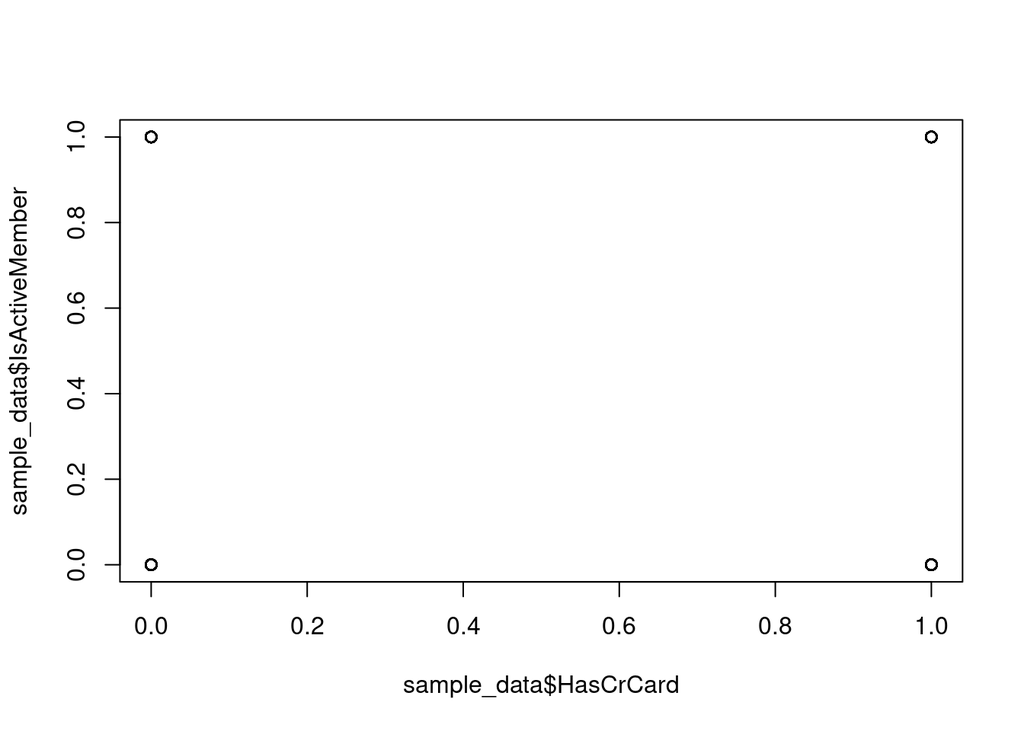

```r
plot(sample_data$HasCrCard, sample_data$IsActiveMember)
```

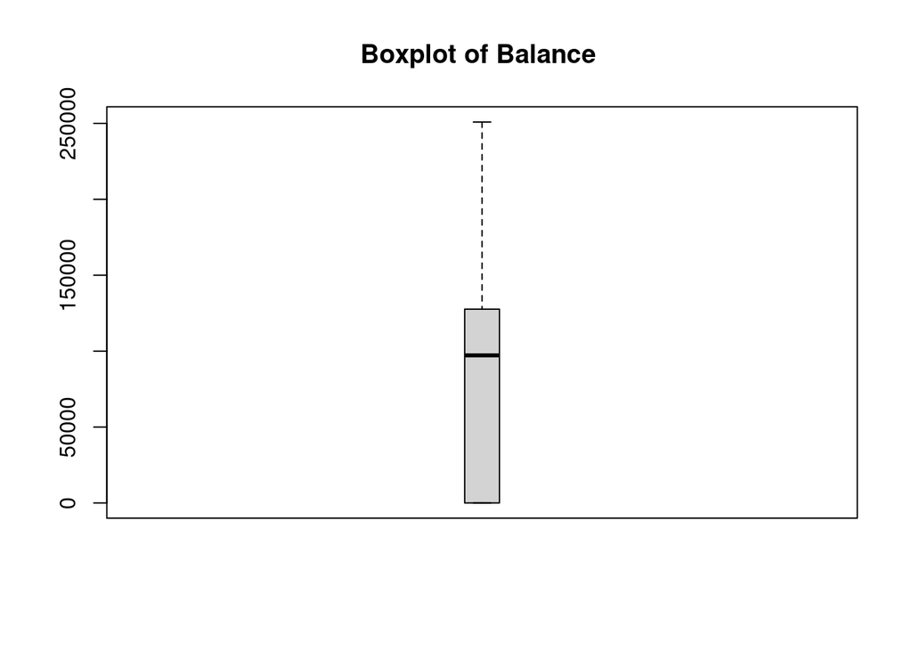

```r
boxplot(sample_data$Balance  , main= "Boxplot of Balance " , boxwex=0.1)
```

```r
sample_data$Balance[sample_data$Balance > 150000]
```

```
##   [1] 159660.8 155931.1 152328.9 169831.5 150725.5 163607.2 157780.8 178718.2
##   [9] 176274.0 150092.8 154475.5 167864.4 185173.8 152603.5 213146.2 169462.1
##  [17] 190479.5 161608.8 162150.4 174790.1 176666.6 161814.6 170557.9 152400.5
##  [25] 184686.4 174186.0 166297.9 156847.3 153804.4 182123.8 150923.7 165272.1
##  [33] 170331.4 169399.6 187842.0 150842.9 152265.4 152390.3 161526.0 183102.3
##  [41] 155726.9 152958.3 181461.5 162923.9 168190.3 174937.6 156478.6 155470.5
##  [49] 180075.2 156067.0 170061.9 169089.4 211774.3 152828.0 151226.2 169312.1
##  [57] 154963.0 152968.7 158261.7 170491.8 157296.0 174318.1 162448.7 150525.8
##  [65] 170185.0 167878.5 164113.0 150461.1 164870.8 193858.2 176099.1 178820.9
##  [73] 181656.5 168286.8 209767.3 169824.5 151859.0 156325.4 160980.0 177619.7
##  [81] 166733.9 157120.9 156092.0 177640.1 167997.6 187530.7 167773.0 157993.1
##  [89] 156021.3 164284.7 154333.8 186796.4 170826.5 153895.6 190227.5 172448.8
##  [97] 170833.5 163943.9 173340.8 171770.5 161064.6 174912.7 192390.5 151607.6
## [105] 156371.6 197041.8 151839.3 168197.7 167738.8 175159.9 173434.9 179380.7
## [113] 153946.1 155413.1 152169.1 214347.0 170935.9 185891.5 158456.8 155663.3
```

[output cut: 107 more lines]

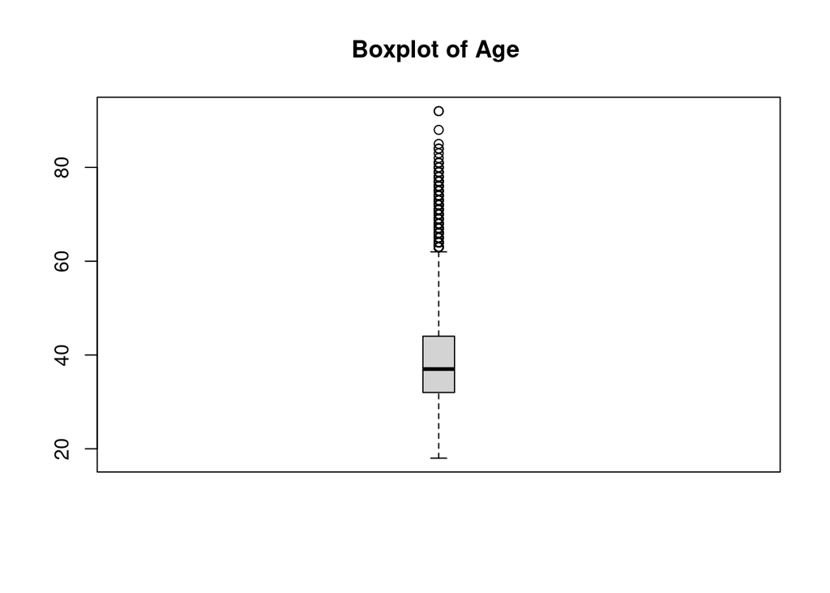

```r
boxplot(sample_data$Age  , main= "Boxplot of Age " , boxwex=0.1)
```

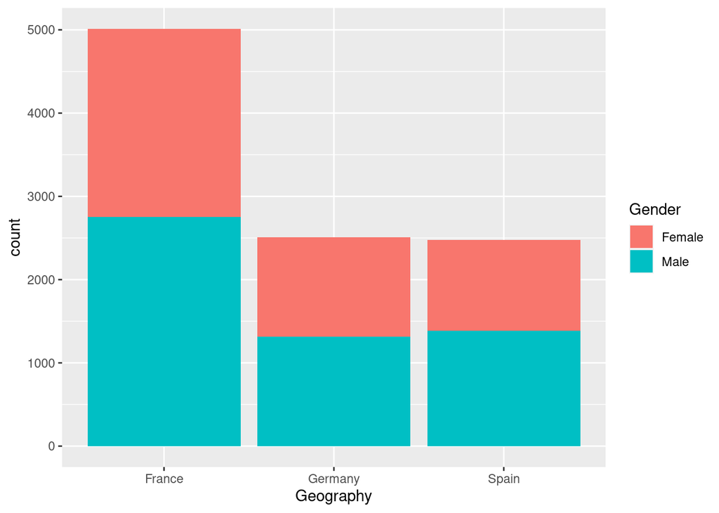

```r
ggplot(data = sample_data) +
geom_bar(mapping = aes(x = Geography, fill= Gender))
```

# Summary of the EDA

##### 3. From the bar_plot we can see There is no gender skewness.

##### 4. Customers are from 3 different coutries. France, Germany and Spain. Most of them are from France

# Feature engineering

### Pearson’s Chi-squared test

```r
# Converting character variables to factors for analysis
sample_data <- sample_data %>%
  mutate(
    Surname = as.factor(Surname),
    Geography = as.factor(Geography),
    Gender = as.factor(Gender)
  )

# Performing chi-squared test for categorical variables against the target 'Exited'
categorical_vars <- c("Surname", "Geography", "Gender")

# Function to perform chi-squared test and extract p-values
chi_squared_test <- function(var) {
  chisq <- chisq.test(sample_data[[var]], sample_data$Exited)
  p_value <- chisq$p.value
  return(data.frame(Variable = var, P_Value = p_value))
}

# Applying chi-squared test for each categorical variable
chi_squared_results <- map_df(categorical_vars, chi_squared_test)
# Filter attributes with significant p-values (e.g., p-value < 0.05)
significant_attributes <- chi_squared_results %>%
  filter(P_Value < 0.05) %>%
  pull(Variable)

# Show significant attributes
print(significant_attributes)
```

```
## [1] "Geography" "Gender"
```

## Feature selection

The first column is called RowNumber, and it just enumerates the rows. We should drop this feature, because row number shouldn’t have any correlation with whether or not a customer churned.The same is true for CustomerID, which appears to be a number assigned to the customer for administrative purposes, and Surname, which is the customer’s last name. Since these cannot be expected to have any influence over the target variable, we can remove them from the modeling dataset.Finally, for ethical reasons, we should remove the Gender column. The reason for doing this is that we don’t want our model-making predictions (and therefore, offering promotions/financial incentives) based on a person’s gender.

```r
sample_data2 <- subset(sample_data, select = -c(RowNumber, CustomerId, Surname, Gender))
```

```r
head(sample_data2)
```

```
## # A tibble: 6 × 10
##   CreditScore Geography   Age Tenure Balance NumOfProducts HasCrCard
##         <dbl> <fct>     <dbl>  <dbl>   <dbl>         <dbl>     <dbl>
## 1         619 France       42      2      0              1         1
## 2         608 Spain        41      1  83808.             1         0
## 3         502 France       42      8 159661.             3         1
## 4         699 France       39      1      0              2         0
## 5         850 Spain        43      2 125511.             1         1
## 6         645 Spain        44      8 113756.             2         1
## # ℹ 3 more variables: IsActiveMember <dbl>, EstimatedSalary <dbl>, Exited <dbl>
```

## Feature extraction

Adding new column Loyalty. The logic behind using tenure and dividing it by the customer’s age is that it represents the percentage of a person’s life that they’ve been customers of the bank. People with greater percentages may be more loyal customers.

```r
sample_data2$Loyalty <- sample_data2$Tenure/sample_data2$Age
head(sample_data2)
```

```
## # A tibble: 6 × 11
##   CreditScore Geography   Age Tenure Balance NumOfProducts HasCrCard
##         <dbl> <fct>     <dbl>  <dbl>   <dbl>         <dbl>     <dbl>
## 1         619 France       42      2      0              1         1
## 2         608 Spain        41      1  83808.             1         0
## 3         502 France       42      8 159661.             3         1
## 4         699 France       39      1      0              2         0
## 5         850 Spain        43      2 125511.             1         1
## 6         645 Spain        44      8 113756.             2         1
## # ℹ 4 more variables: IsActiveMember <dbl>, EstimatedSalary <dbl>,
## #   Exited <dbl>, Loyalty <dbl>
```

## Feature transformation

```r
sample_data2$Geography <-  as.integer(factor(sample_data2$Geography))
head(sample_data2)
```

```
## # A tibble: 6 × 11
##   CreditScore Geography   Age Tenure Balance NumOfProducts HasCrCard
##         <dbl>     <int> <dbl>  <dbl>   <dbl>         <dbl>     <dbl>
## 1         619         1    42      2      0              1         1
## 2         608         3    41      1  83808.             1         0
## 3         502         1    42      8 159661.             3         1
## 4         699         1    39      1      0              2         0
## 5         850         3    43      2 125511.             1         1
## 6         645         3    44      8 113756.             2         1
## # ℹ 4 more variables: IsActiveMember <dbl>, EstimatedSalary <dbl>,
## #   Exited <dbl>, Loyalty <dbl>
```

# Naive Bayes

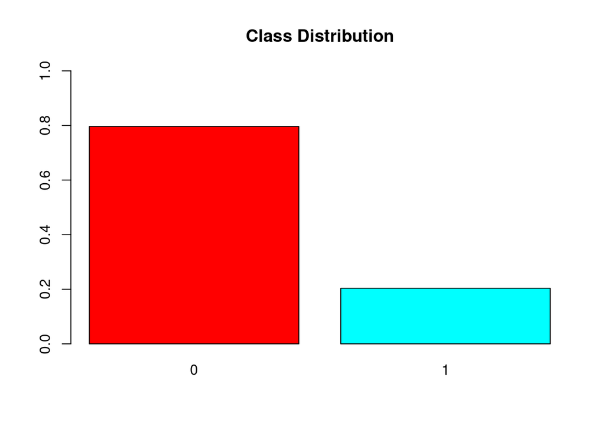

```r
barplot(prop.table(table(sample_data2$Exited)),
        col = rainbow(2),
        ylim = c(0, 1),
        main = "Class Distribution")
```

First, we’ll check the class balance of the exited column which is our target variable.The class is split roughly 80/20. In other words, about 20% of the people in this dataset churned. This is an unbalanced data set, but it’s not extreme. So we’ll proceed without doing any class re-balancing of our target variable.

When we prepared our data, we engineered a feature called loyalty by dividing tenure by age. Because this new feature is just the quotient of two existing variables, it’s no longer conditionally independent. So we’re going to drop tenure and age.

```r
sample_data3 <- subset(sample_data2, select = -c(Age, Tenure))
head(sample_data3)
```

```
## # A tibble: 6 × 9
##   CreditScore Geography Balance NumOfProducts HasCrCard IsActiveMember
##         <dbl>     <int>   <dbl>         <dbl>     <dbl>          <dbl>
## 1         619         1      0              1         1              1
## 2         608         3  83808.             1         0              1
## 3         502         1 159661.             3         1              0
## 4         699         1      0              2         0              0
## 5         850         3 125511.             1         1              1
## 6         645         3 113756.             2         1              0
## # ℹ 3 more variables: EstimatedSalary <dbl>, Exited <dbl>, Loyalty <dbl>
```

### Splitting Data into Train and Test sets

```r
# Splitting the data into predictors (X) and target variable (y)
X <- sample_data3 %>%
  select(-Exited) # Exclude the target variable 'Exited'
y <- sample_data3$Exited

# Dividing the data into training and test sets (70% training, 30% test)
set.seed(123) # Set seed for reproducibility
train_indices <- createDataPartition(y, p = 0.7, list = FALSE)
train_data <- sample_data3[train_indices, ]
test_data <- sample_data3[-train_indices, ]
```

### Predictive accuracy of the Naive Bayes classifier

```r
nb_model <- naiveBayes(Exited ~ ., data = train_data, laplace = 1)  # Set laplace parameter (smoothing) to 1 or another appropriate value

# Predicting on the test set using the trained model
predicted_test <- predict(nb_model, newdata = test_data)
# Convert 'Exited' column to factor with same levels as predicted values
test_data$Exited <- factor(test_data$Exited, levels = levels(predicted_test))

# Calculating accuracy on the test set (train-test split approach)
accuracy_test <- confusionMatrix(predicted_test, test_data$Exited)$overall['Accuracy']
print(accuracy_test)
```

```
##  Accuracy
## 0.8196667
```

This code illustrates the process of training a Naive Bayes model, making predictions on a test set, and quantifying the overall accuracy of the model’s predictions. Adjustments to Laplace smoothing or other evaluation metrics can be made based on specific project requirements and data characteristics.

### K-fold cross validation

```r
# Create an empty vector to store accuracy values for each fold
accuracy_values <- numeric(10)

# Create indices for 10-fold cross-validation
folds <- cut(seq(1, nrow(sample_data3)), breaks = 10, labels = FALSE)

# Perform 10-fold cross-validation
for (i in 1:10) {
  # Define the test set and training set for this fold
  test_indices <- which(folds == i)
  test_data <- sample_data3[test_indices, ]
  train_data <- sample_data3[-test_indices, ]

  # Train the Naïve Bayes classifier using the training data
  nb_model <- naiveBayes(Exited ~ ., data = train_data)

  # Predict on the test set
  predicted <- predict(nb_model, newdata = test_data)

  # Calculate accuracy for this fold
  correct_predictions <- sum(predicted == test_data$Exited)
  fold_accuracy <- correct_predictions / nrow(test_data)

  # Store the accuracy value
  accuracy_values[i] <- fold_accuracy
}

# Compute the average accuracy across all folds
cv_accuracy <- mean(accuracy_values)
print(cv_accuracy)
```

```
## [1] 0.8184
```

This code snippet demonstrates the implementation of 10-fold cross-validation to evaluate a Naive Bayes classifier’s performance. Created an empty numeric vector accuracy_values to store accuracy values for each fold. Defined indices for 10-fold cross-validation using cut() function to split the dataset into 10 folds. Then Splitted the data into training and test sets for each fold, trains the Naive Bayes model, makes predictions, and computes accuracy for each fold, storing the values in accuracy_values. At last calculated the average accuracy across all folds by computing the mean of accuracy_values.

### Confusion matrix

```r
# Train the Naïve Bayes classifier using the full dataset
nb_model_full <- naiveBayes(Exited ~ ., data = sample_data3)

# Predicting on the full dataset using the trained model
predicted_full <- predict(nb_model_full, newdata = sample_data3)

# Ensure both variables are factors with the same levels
predicted_full <- factor(predicted_full, levels = c("0", "1"))  # Replace with your levels if different
sample_data3$Exited <- factor(sample_data3$Exited, levels = c("0", "1"))  # Replace with your levels if different

# Generate confusion matrix
conf_matrix <- confusionMatrix(predicted_full, sample_data3$Exited)
print("Confusion Matrix:")
```

```
## [1] "Confusion Matrix:"
```

```r
print(conf_matrix$table)
```

```
##           Reference
## Prediction    0    1
##          0 7941 1791
##          1   22  246
```

### Recall, Precision and F- measure

```r
recall <- conf_matrix$byClass["Recall"]
precision <- conf_matrix$byClass["Precision"]
f_measure <- conf_matrix$byClass["F1"]
print(paste("Recall:", recall))
```

```
## [1] "Recall: 0.997237222152455"
```

```r
print(paste("Precision:", precision))
```

```
## [1] "Precision: 0.81596794081381"
```

```r
print(paste("F-measure:", f_measure))
```

```
## [1] "F-measure: 0.897541678440237"
```

Precision measures the accuracy of positive predictions made by the model. It’s calculated as the ratio of true positive predictions to the sum of true positives and false positives. Formula: Precision = TP / (TP + FP)

Recall measures the ability of the model to correctly identify positive instances from all actual positive instances. It calculates the ratio of true positive predictions to the sum of true positives and false negatives. Formula: Recall = TP / (TP + FN)

F-measure is the harmonic mean of precision and recall. It provides a balance between precision and recall. F1-score reaches its best value at 1 (perfect precision and recall) and worst at 0. Formula: F1-score = 2 * (Precision * Recall) / (Precision + Recall)